# Eigenvektori

MVedak

2022-12-06

Učitavanje potrebnih paketa:

## Inicijalno učitavanje i obrada podataka

Prije izvoda ikakve analize potrebno je učitati i očistiti podatke. Učitavanje podataka je vrlo jednostavno, no prije konkretnog korištenja potrebno je modificirati učitani DataFrame kako bi analiza bila moguća.

Prvi problem koji se pojavio je činjenica da R automatski prepoznaje tip podataka u kolumnama, te je kolumni “Min” prepoznao kao kolumnu koja sadrži stringove, dok je ona u realnosti numerička (do ovoga dolazi jer kolumna sadrži ‘,’ character). Nažalost, ovaj problem se ne može instantno riješiti funkcijom as.numeric već moramo prije toga eliminirati ‘,’ koji odvaja tisućice od stotica.

```r
players <- read.csv("Statistika nogometaša engleske Premier lige.csv", stringsAsFactors = FALSE)
players$Min <- as.numeric(gsub(",", "", players$Min))
```

Pogledajmo sada naš dataset:

```r
head(players)
```

```
##               Player    Team     Nation   Pos Age MP Starts  Min X90s Gls Ast
## 1        Bukayo Saka Arsenal eng\xa0ENG FW,MF  19 38     36 2978 33.1  11   7
## 2 Gabriel Dos Santos Arsenal  br\xa0BRA    DF  23 35     35 3063 34.0   5   0
## 3     Aaron Ramsdale Arsenal eng\xa0ENG    GK  23 34     34 3060 34.0   0   0
## 4          Ben White Arsenal eng\xa0ENG    DF  23 32     32 2880 32.0   0   0
## 5 Martin \xd8degaard Arsenal  no\xa0NOR    MF  22 36     32 2785 30.9   7   4
## 6       Granit Xhaka Arsenal  ch\xa0SUI MF,DF  28 27     27 2327 25.9   1   2
##   G.PK PK PKatt CrdY CrdR Gls.1 Ast.1  G.A G.PK.1 G.A.PK  xG npxG  xA npxG.xA
## 1    9  2     2    6    0  0.33  0.21 0.54   0.27   0.48 9.7  8.2 6.9    15.2
## 2    5  0     0    8    1  0.15  0.00 0.15   0.15   0.15 2.7  2.7 0.8     3.5
## 3    0  0     0    1    0  0.00  0.00 0.00   0.00   0.00 0.0  0.0 0.0     0.0
## 4    0  0     0    3    0  0.00  0.00 0.00   0.00   0.00 1.0  1.0 0.6     1.6
## 5    7  0     0    4    0  0.23  0.13 0.36   0.23   0.36 4.8  4.8 6.8    11.6
## 6    1  0     0   10    1  0.04  0.08 0.12   0.04   0.12 1.2  1.2 2.3     3.5
##   xG.1 xA.1 xG.xA npxG.1 npxG.xA.1
## 1 0.29 0.21  0.50   0.25      0.46
## 2 0.08 0.02  0.10   0.08      0.10
## 3 0.00 0.00  0.00   0.00      0.00
## 4 0.03 0.02  0.05   0.03      0.05
## 5 0.16 0.22  0.38   0.16      0.38
## 6 0.05 0.09  0.14   0.05      0.14
```

```r
str(players)
```

```
## 'data.frame':    691 obs. of  30 variables:
##  $ Player   : chr  "Bukayo Saka" "Gabriel Dos Santos" "Aaron Ramsdale" "Ben White" ...
##  $ Team     : chr  "Arsenal" "Arsenal" "Arsenal" "Arsenal" ...
##  $ Nation   : chr  "eng\xa0ENG" "br\xa0BRA" "eng\xa0ENG" "eng\xa0ENG" ...
##  $ Pos      : chr  "FW,MF" "DF" "GK" "DF" ...
##  $ Age      : int  19 23 23 23 22 28 28 24 21 20 ...
##  $ MP       : int  38 35 34 32 36 27 24 22 33 29 ...
##  $ Starts   : int  36 35 34 32 32 27 23 22 21 21 ...
##  $ Min      : num  2978 3063 3060 2880 2785 ...
##  $ X90s     : num  33.1 34 34 32 30.9 25.9 22.5 21.3 21.3 20.7 ...
##  $ Gls      : int  11 5 0 0 7 1 2 1 10 6 ...
##  $ Ast      : int  7 0 0 0 4 2 1 3 2 6 ...
##  $ G.PK     : int  9 5 0 0 7 1 2 1 10 5 ...
##  $ PK       : int  2 0 0 0 0 0 0 0 0 1 ...
##  $ PKatt    : int  2 0 0 0 0 0 0 0 0 1 ...
```

[output cut: 16 more lines]

```r
summary(players)
```

```
##     Player              Team              Nation              Pos
##  Length:691         Length:691         Length:691         Length:691
##  Class :character   Class :character   Class :character   Class :character
##  Mode  :character   Mode  :character   Mode  :character   Mode  :character
##
##
##
##
##       Age              MP            Starts          Min            X90s
##  Min.   :15.00   Min.   : 0.00   Min.   : 0.0   Min.   :   1   Min.   : 0.00
##  1st Qu.:20.00   1st Qu.: 1.00   1st Qu.: 0.0   1st Qu.: 398   1st Qu.: 4.35
##  Median :24.00   Median :14.00   Median : 9.0   Median :1328   Median :14.70
##  Mean   :24.49   Mean   :15.17   Mean   :12.1   Mean   :1376   Mean   :15.26
##  3rd Qu.:28.00   3rd Qu.:28.00   3rd Qu.:22.0   3rd Qu.:2154   3rd Qu.:23.90
##  Max.   :39.00   Max.   :38.00   Max.   :38.0   Max.   :3420   Max.   :38.00
##  NA's   :4                                      NA's   :145    NA's   :144
##       Gls              Ast              G.PK              PK
##  Min.   : 0.000   Min.   : 0.000   Min.   : 0.000   Min.   :0.0000
##  1st Qu.: 0.000   1st Qu.: 0.000   1st Qu.: 0.000   1st Qu.:0.0000
##  Median : 1.000   Median : 1.000   Median : 1.000   Median :0.0000
##  Mean   : 1.896   Mean   : 1.362   Mean   : 1.742   Mean   :0.1536
##  3rd Qu.: 2.000   3rd Qu.: 2.000   3rd Qu.: 2.000   3rd Qu.:0.0000
##  Max.   :23.000   Max.   :13.000   Max.   :23.000   Max.   :6.0000
##  NA's   :144      NA's   :144      NA's   :144      NA's   :144
##      PKatt             CrdY             CrdR             Gls.1
##  Min.   :0.0000   Min.   : 0.000   Min.   :0.00000   Min.   :0.0000
##  1st Qu.:0.0000   1st Qu.: 0.000   1st Qu.:0.00000   1st Qu.:0.0000
##  Median :0.0000   Median : 2.000   Median :0.00000   Median :0.0300
##  Mean   :0.1883   Mean   : 2.452   Mean   :0.07861   Mean   :0.1104
##  3rd Qu.:0.0000   3rd Qu.: 4.000   3rd Qu.:0.00000   3rd Qu.:0.1500
##  Max.   :7.0000   Max.   :11.000   Max.   :2.00000   Max.   :2.0300
##  NA's   :144      NA's   :144      NA's   :144       NA's   :145
##      Ast.1              G.A              G.PK.1           G.A.PK
##  Min.   : 0.0000   Min.   : 0.0000   Min.   :0.0000   Min.   : 0.0000
##  1st Qu.: 0.0000   1st Qu.: 0.0000   1st Qu.:0.0000   1st Qu.: 0.0000
##  Median : 0.0300   Median : 0.1000   Median :0.0300   Median : 0.1000
##  Mean   : 0.1003   Mean   : 0.2107   Mean   :0.1032   Mean   : 0.2034
##  3rd Qu.: 0.1200   3rd Qu.: 0.2900   3rd Qu.:0.1400   3rd Qu.: 0.2800
##  Max.   :11.2500   Max.   :11.2500   Max.   :2.0300   Max.   :11.2500
##  NA's   :145       NA's   :145       NA's   :145      NA's   :145
```

[output cut: 9 more lines]

```
##  Min.   :0.0000   Min.   :0.00000   Min.   :0.00   Min.   :0.0000
##  1st Qu.:0.0200   1st Qu.:0.01000   1st Qu.:0.05   1st Qu.:0.0125
##  Median :0.0600   Median :0.06000   Median :0.13   Median :0.0600
##  Mean   :0.1372   Mean   :0.09262   Mean   :0.23   Mean   :0.1301
##  3rd Qu.:0.1700   3rd Qu.:0.12000   3rd Qu.:0.33   3rd Qu.:0.1600
##  Max.   :4.4800   Max.   :6.50000   Max.   :6.50   Max.   :4.4800
##  NA's   :145      NA's   :145       NA's   :145    NA's   :145
##    npxG.xA.1
##  Min.   :0.000
##  1st Qu.:0.050
##  Median :0.130
##  Mean   :0.223
##  3rd Qu.:0.310
##  Max.   :6.500
##  NA's   :145
```

Podatci izgledaju dobro i možemo primjetiti par stvari:

1. Igrači koji su odigrali 0 utakmica (MP=0) nemaju podatke o golovima, asistencijama i sličnim kolumnama (X90s, GLs, … = NA) te za neke fali informacija o minutama igre. Ovo nije problem jer to znači da ove vrijednosti koje fale trebaju biti 0.
2. Za određene igrače fali informacija o njihovim godinama. Ovo predstavlja problem koji treba riješiti. Najjednostavnije rješenje ovog problema bi bilo pronalazak tih informacija i ručna nadopuna. Postoje i razni drugi načini nadopune podataka koji fale, načini koji su utemeljeni na statističkim svojstvima svih podataka. Mi smo se odlučili za pristup izbacivanja takvih podataka - dataset je dovoljno velik (691 podatak), i broj igrača za koje ne postoji informacija o godinama (njih 4) je dovoljno malen da bi ovakav pristup funkcionirao.

```r
players <- players[!is.na(players$Age),]
```

## 1. zadatak: postoji li razlika u broju odigranih minuta mladih igrača (do 25 godina) među premierligaškim ekipama?

Da bi odgovorili na ovaj zadatak, potrebne su nam samo dvije kolumne iz našeg dataseta: kolumna o godinama (Age) te kolumna o odigranim minutama (Min). Kolumnu Age smo već očistili od nepostojećih podataka, dok kolumnu Min trebamo popraviti - popuniti nepostojeće podatke nulama. Učinimo to sada.

```r
players <- players %>% mutate(Min = coalesce(Min, 0))
```

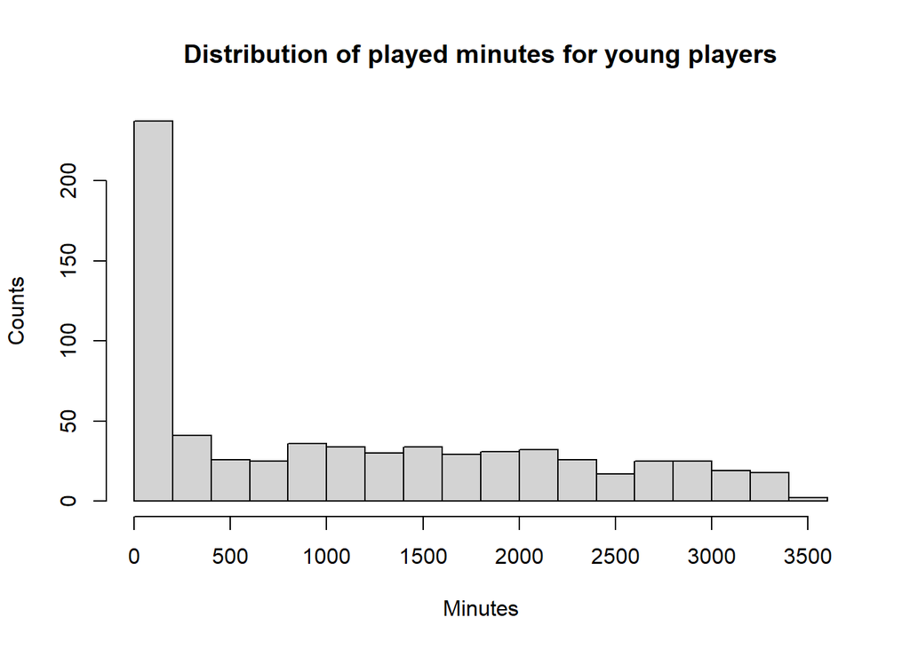

```r
# Izdvajanje mladih igrača (do 25 godina)
young_players <- players[players$Age <= 25,]

hist(players$Min, breaks=20, main="Distribution of played minutes for young players", xlab="Minutes", ylab="Counts")
```

Iz grafa možemo zaključiti da velik broj igrača ne igra utakmice ili igraju jako malo, dok uspješniji igrači imaju podjednaku distribuciju odigranih minuta sve do 3500.

Pregled distribucija minuta po timovima je malo složenija vizualizacija - iskoristit ćemo box-plot po timovima.

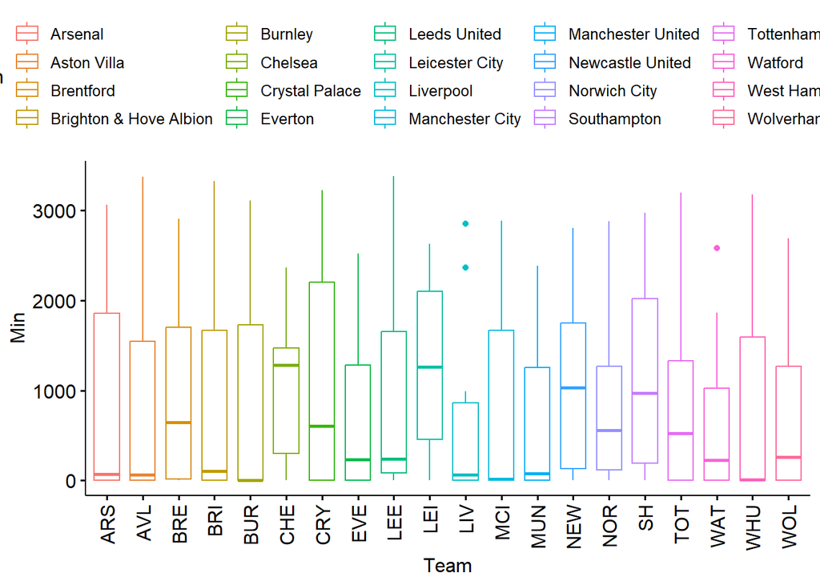

```r
ggboxplot(young_players, x = "Team", y = "Min", color = "Team", font.label = list(size=20)) + scale_x_discrete(labels = c("ARS", "AVL", "BRE", "BRI", "BUR", "CHE", "CRY", "EVE", "LEE", "LEI", "LIV", "MCI", "MUN", "NEW", "NOR", "SH", "TOT", "WAT", "WHU", "WOL")) + rotate_x_text()
```

Pogledajmo još distribuciju odigranih minuta za određenu ekipu, recimo Leicester City.

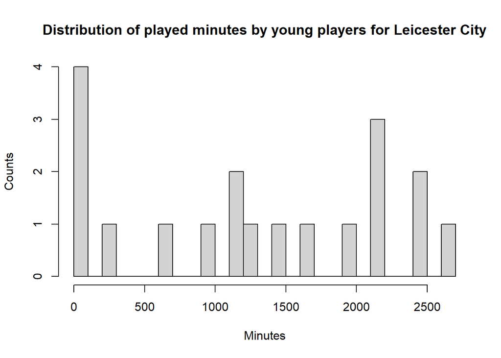

```r
leicester_young_players <- young_players[young_players$Team == "Leicester City",]
hist(leicester_young_players$Min, breaks=20, main="Distribution of played minutes by young players for Leicester City", xlab="Minutes", ylab="Counts")
```

Krenimo sada s analizom pitanja. Da bi odgovorili na ovo pitanje moramo usporediti distribuciju odigranih minuta svih timova premier lige (njih 20). Činjenica da je broj skupina koje uspoređujemo veći od 2 odbacuje mogućnost korištenja “jednostavnih” statističkih testova poput t-testa. Metoda koja nam omogućuje statistički odgovor na zadano pitanje je ANOVA (Analysis of Variance).

ANOVA je statistički test koji nam govori jesu li sredine dviju ili više populacija jednake, te je generalizacija t-testa na više od dvije distribucije. Drugim riječima, nulta hipoteza ANOVE je da su srednje vrijednosti svih testiranih populacija jednake, a sukladna p-vrijednost nam govori kolika je vjerojatnost da dobijemo viđenu populacijom pod pretpostavkom nasumičnog uzorkovanja iz distribucija jednakih srednjih vrijednosti.

ANOVA koristi sljedeće pretpostavke:

1. Normalnost: podaci moraju biti normalno distribuirani u svakoj skupini.
2. Homogenost varijance: varijanca svake skupine mora biti jednaka.
3. Nezavisnost: podaci u svakoj skupini moraju biti neovisni jedni od drugih. Iz prijašnjih grafova, možemo vidjeti da pretpostavka normalnosti ne vrijedi (formalno, mogli bi odraditi neki test i provjeriti statistički da dane distribucije populacija nisu normalne, no u ovom slučaju mislimo da je to vrlo jasno vizualno vidljivo). To znači da ANOVA vjerojatno neće dati dobre rezultate.

Srećom, postoji alternativa: neparametarski test, Kruskal-Wallisov test. Kruskal-Wallis test će izračunati p-vrijednost koja odgovara na pitanje: postoji li značajna razlika u broju odigranih minuta među timovima za mlađe igrače. Ako je p-vrijednost manja od zadane razine značajnosti (obično 0,05), onda možemo zaključiti da postoji značajna razlika u broju odigranih minuta među timovima za mlađe igrače. Uvjet provođenja Kruskal-Wallisovog testa je da veličina svakog uzorka mora biti barem 5, što u našem slučaju vrijedi.

1. $H_0$: medijani distribucija svih uzoraka su jednaki. $H_1$: barem dva medijana nisu jednaka
2. Uzmimo razinu značajnosti $\alpha = 0.05$.

```r
# Kruskal-Wallis test
result <- kruskal.test(Min ~ Team, data = young_players)

print(result)
```

```
##
##  Kruskal-Wallis rank sum test
##
## data:  Min by Team
## Kruskal-Wallis chi-squared = 15.753, df = 19, p-value = 0.6737
```

Dobivena p-vrijednost je $0.6737$, mnogo veća od $0.05$. Ne možemo odbaciti nultu hipotezu $H_0$ te zaključujemo da ne postoji razlika među odigranim minutama mladih igrača između timova premier lige.

## 2. zadatak: dobivaju li u prosjeku više žutih kartona napadači ili igrači veznog reda?

Da bi odgovorili na ovo pitanje, koristit ćemo tri kolumne u zadanom datasetu: broj dobivenih žutih karton (CrdY), poziciju igrača (Pos), te broj odigranih utakmica (MP).

Kao i prije, imamo problem s jednom od kolumni: neke vrijednosti CrdY fale. Za igrače koji nisu odigrali niti jednu minutu utakmica logično da vrijednost broja dobivenih žutih kartona fali. Taj broj dobivenih žutih kartona je tehnički 0, no smatramo da ovdje treba razlikovati igrače koji su odigrali neke utakmice i nisu dobili niti jedan žuti karton (valjana pretpostavka je da igraju “čisto”, ne krše protivnike), za razliku od igrača koji uopče nisu igrali - ne možemo zaključiti da igraju “čisto” ili “prljavo”. Igrače koji nisu uopće igrali ćemo izbaciti.

```r
players_who_played <- players[players$MP > 0, c("Player", "Team", "Pos", "MP", "CrdY")]
```

Dalje, vjerojatnost da igrač dobije žuti karton sigurno raste s količinom odigranih minuta. No, kako igrač može dobiti maksimalno 2 žuta kartona po utakmici, više smisla ima gledati broj žutih kartona po utakmici. U tu svrhu, umjesto direktne usporedbe broja žutih kartona, uspoređivati ćemo broj žutih kartona po broju odigranih utakmica (nazovimo to CrdY.MP)

```r
players_who_played$CrdY.MP <- players_who_played$CrdY / players_who_played$MP
```

Pogledajmo kako izgledaju ti podaci.

```r
summary(players_who_played)
```

```
##     Player              Team               Pos                  MP
##  Length:546         Length:546         Length:546         Min.   : 1.00
##  Class :character   Class :character   Class :character   1st Qu.: 9.00
##  Mode  :character   Mode  :character   Mode  :character   Median :20.00
##                                                           Mean   :19.20
##                                                           3rd Qu.:29.75
##                                                           Max.   :38.00
##       CrdY           CrdY.MP
##  Min.   : 0.000   Min.   :0.00000
##  1st Qu.: 0.000   1st Qu.:0.00000
##  Median : 2.000   Median :0.09091
##  Mean   : 2.454   Mean   :0.11597
##  3rd Qu.: 4.000   3rd Qu.:0.18182
##  Max.   :11.000   Max.   :1.00000
```

```r
position_counts <- table(players_who_played$Pos)
kable(position_counts, caption = "Table 1: Number of players by their positions", align="c")
```

Table 1: Number of players by their positions

| Var1 | Freq |
| --- | --- |
| DF | 185 |
| DF,FW | 4 |
| DF,MF | 5 |
| FW | 83 |
| FW,DF | 2 |
| FW,MF | 59 |
| GK | 42 |
| MF | 116 |
| MF,DF | 11 |
| MF,FW | 39 |

Napokon, preostaje diskusija o kolumni pozicije (Pos). Ona je vrlo jednostavna: opisuje koju poziciju igra koji igrač. Pojedini igrači su svrstani u više kategorija, poput napadača i veznog igrača. U ovom zadatku, nas interesiraju samo napadači (FW) te vezni igrači (MF). Iz tablice 1 možemo vidjeti da imamo podatke o 83 napadača, 116 veznih igrača, 59 napadača/veznih, 39 veznih/napadača. Kod kombiniranih pozicija, pretpostavljamo da je prvo napisana ona pozicija koju napadač preferira/većinom igra, te ćemo tako napadača/veznog (FW,MF) igrača svrstati kao čistog napadača (FW), a veznog/napadača (MF,FW) kao veznog igrača (MF).

```r
players_who_played$Pos[players_who_played$Pos == "FW,MF"] <- "FW"
players_who_played$Pos[players_who_played$Pos == "MF,FW"] <- "MF"
midfielders_and_forwards = players_who_played[players_who_played$Pos == "FW" | players_who_played$Pos == "MF",]
```

Kao i u prijašnjem zadatku, prije ikakve analize vizualizirat ćemo dane podatke.

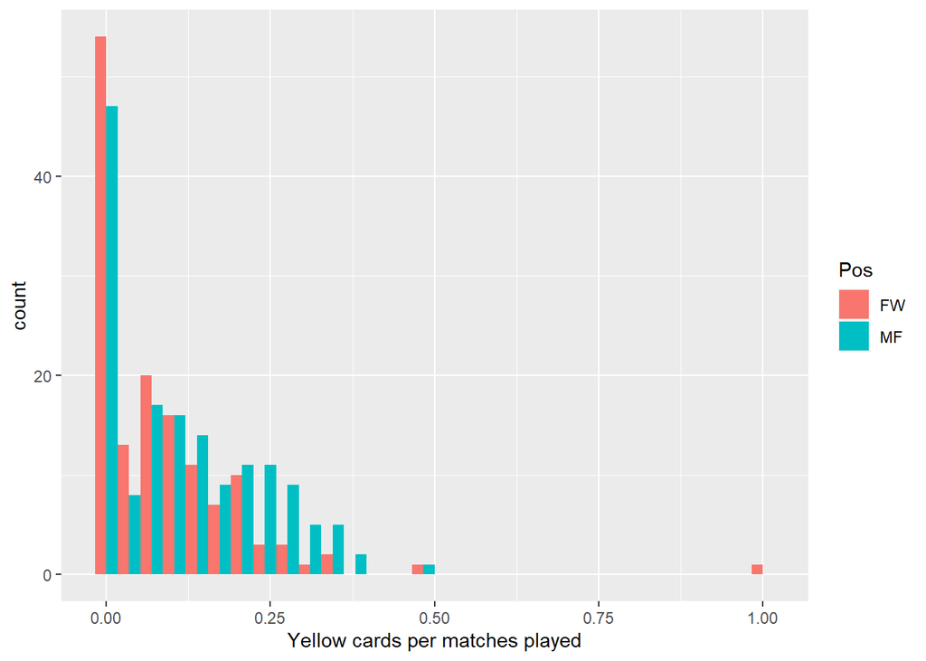

```r
# Create a histogram of the column 'CrdY.MP' split by the column 'MP'
ggplot(midfielders_and_forwards, aes(x = CrdY.MP, fill = Pos)) +
  geom_histogram(position = "dodge") + xlab("Yellow cards per matches played")
```

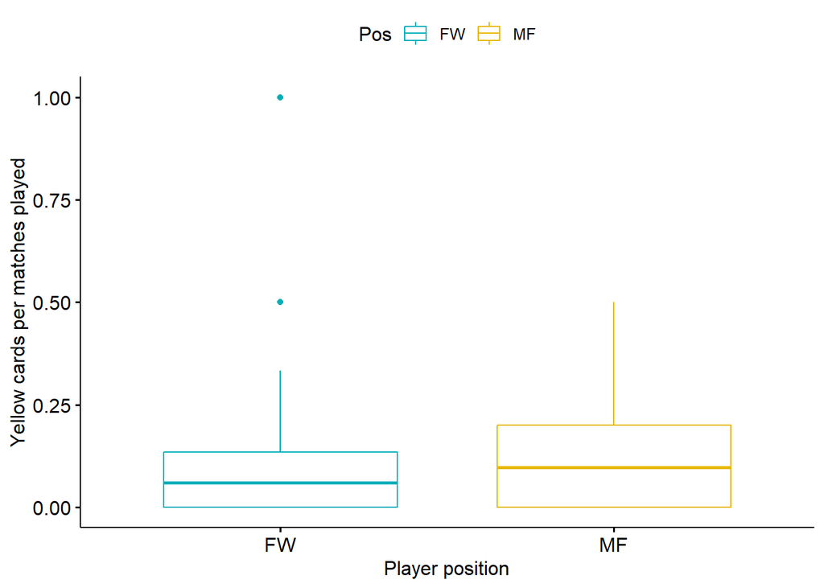

```r
ggboxplot(midfielders_and_forwards, x = "Pos", y = "CrdY.MP",
          color = "Pos", palette = c("#00AFBB", "#E7B800"),
          ylab = "Yellow cards per matches played", xlab = "Player position")
```

Dvije populacije koje uspoređujemo nisu normalne. To znači da ne možemo koristiti standardan t-test. U spas ponovno dolaze neparametarski testovi - specifično Wilcoxonov rank-sum test. On uspoređuje medijan dva uzorka. Test je baziran na ukupnim rangovima observacija, a ne na konkretnim vrijednostima.

Postava eksperimenta je slijedeća:

- Nulta hipoteza $H_0$: medijani su jednaki
- Alternativna hipoteza $H_1$: medijan veznih igrača je veći od medijana napadača
- Uzimamo razinu signifikantnosti od $\alpha=0.05$

```r
wilcox.test(midfielders_and_forwards$CrdY.MP[midfielders_and_forwards$Pos == "FW"], midfielders_and_forwards$CrdY.MP[midfielders_and_forwards$Pos == "MF"], alternative = "less")
```

```
##
##  Wilcoxon rank sum test with continuity correction
##
## data:  midfielders_and_forwards$CrdY.MP[midfielders_and_forwards$Pos == "FW"] and midfielders_and_forwards$CrdY.MP[midfielders_and_forwards$Pos == "MF"]
## W = 8999.5, p-value = 0.002828
## alternative hypothesis: true location shift is less than 0
```

Dobivena p-vrijednost iznosi 0.0028, stoga možemo s razinom signifikantnosti od $1%$ odbaciti nultu hipotezu.

## 3. zadatak: možete li na temelju zadanih parametara odrediti uspješnost pojedinog igrača?

Predvidljivost uspješnosti pojedinog igrača zahtjeva definiciju uspješnosti. Budući da je zadani dataset relativno slabo informativan (nedostaju informacije poput broju dodavanja, broju driblinga i slično, što definira uspješnost braniča) odlučili smo se za jednostavnu metriku uspješnosti: broj zabijenih golova + broj asistencija. Također, predviđanje će biti odrađeno samo na napadačima jer pozicija napadača je definirana brojem zabijenih golova i asistencijama, dok braniči i vezni igrači generalno imaju nešto drugačije definicije uspješnosti.

U linearnu regresiju su ugrađene neke pretpostavke koje valja spomenuti: 1. Linearnost zavisnih varijabli o varijablama koje objašnjavaju 2. Normalnost grešaka 3. Neovisnost grešaka 4. Homoskedastičnost (jednakost varijanci??) 5. Ne smije biti multikolinearnosti

Kao i u prijašnjem zadatku, uzimamo samo igrače koji su odigrali barem jednu utakmicu. Također, igrače kojima piše da igraju poziciju “FW,MF” svrstavamo u napadače.

```r
forward_players = players[players$MP > 0 & (players$Pos == "FW" | players$Pos == "FW,MF"),]

# Create new column 'Gls+Ast'
forward_players$GlsAst <- forward_players$Gls + forward_players$Ast

# Split data into train and test sets
set.seed(110)  # for reproducibility
train_index <- sample(1:nrow(forward_players), 0.9*nrow(forward_players))
train_data <- forward_players[train_index, ]
test_data <- forward_players[-train_index, ]

# Perform linear regression on train data
model <- lm(GlsAst ~ MP + Min + PK + CrdY + CrdR + xG + xA, data = train_data)

# Print summary of model
summary(model)
```

```
##
## Call:
## lm(formula = GlsAst ~ MP + Min + PK + CrdY + CrdR + xG + xA,
##     data = train_data)
##
## Residuals:
##     Min      1Q  Median      3Q     Max
## -4.9477 -0.9753  0.0532  0.6860  5.6336
##
## Coefficients:
##               Estimate Std. Error t value Pr(>|t|)
## (Intercept) -0.4180695  0.3490420  -1.198    0.233
## MP           0.0384632  0.0403128   0.954    0.342
## Min         -0.0004090  0.0006586  -0.621    0.536
## PK          -0.0453743  0.2038567  -0.223    0.824
## CrdY        -0.0068625  0.1154469  -0.059    0.953
## CrdR         0.8037322  0.7172929   1.121    0.265
## xG           1.0552688  0.0776411  13.592  < 2e-16 ***
## xA           0.9688707  0.1532142   6.324 4.64e-09 ***
## ---
## Signif. codes:  0 '***' 0.001 '**' 0.01 '*' 0.05 '.' 0.1 ' ' 1
##
## Residual standard error: 1.885 on 119 degrees of freedom
## Multiple R-squared:  0.9297, Adjusted R-squared:  0.9255
## F-statistic: 224.7 on 7 and 119 DF,  p-value: < 2.2e-16
```

```r
tidy(model)
```

```
## # A tibble: 8 × 5
##   term         estimate std.error statistic  p.value
##   <chr>           <dbl>     <dbl>     <dbl>    <dbl>
## 1 (Intercept) -0.418     0.349      -1.20   2.33e- 1
## 2 MP           0.0385    0.0403      0.954  3.42e- 1
## 3 Min         -0.000409  0.000659   -0.621  5.36e- 1
## 4 PK          -0.0454    0.204      -0.223  8.24e- 1
## 5 CrdY        -0.00686   0.115      -0.0594 9.53e- 1
## 6 CrdR         0.804     0.717       1.12   2.65e- 1
## 7 xG           1.06      0.0776     13.6    5.70e-26
## 8 xA           0.969     0.153       6.32   4.64e- 9
```

Rezultati linearni regresije su očekivani: očekivani golovi i očekivane asistencije najviše doprinose našoj definiciji uspješnosti te možemo zaključiti da je broj golova liarno ovisan o te dvije varijable na razini značajnosti boljoj od $1\%$. Pogledajmo tu linearnu ovisnost na grafu.

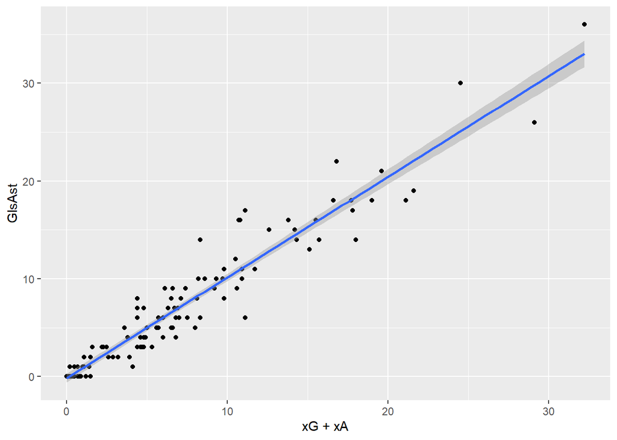

```r
ggplot(train_data, aes(x = xG + xA, y = GlsAst)) + geom_point() + geom_smooth(aes(y=GlsAst), method = "lm")
```

Jedan zanimljiv rezltat linearne regresije je taj što broj dobivenih crvenih kartona ima relativno velik utjecaj na konačan broj zabijenih golova i asistencija. Doduše, $p$-vrijednost CrdR kolumne je ipak 0.26 što je daleko od statistički značajnog. Svejedno, pogledajmo kako broj crvenih kartona utječe na broj zabijenih golova i asistencija.

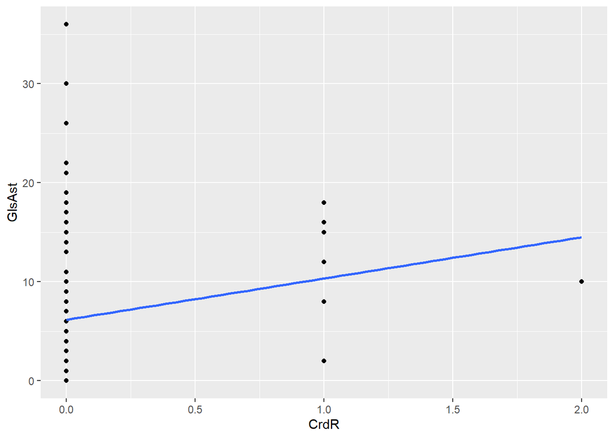

```r
ggplot(train_data, aes(x = CrdR, y = GlsAst)) + geom_point() + geom_smooth(aes(y=GlsAst), method = "lm", se=F)
```

Odokativno, čini se da broj crvenih kartona ipak nije linearno koreliran s brojem zabijenih golova i asistencija.

To možemo i potvrditi eliminacijom varijabli koje ne objašnjavaju varijablu nad kojom regresiramo.

```r
model2 <- step(model)
```

```
## Start:  AIC=168.78
## GlsAst ~ MP + Min + PK + CrdY + CrdR + xG + xA
##
##        Df Sum of Sq     RSS    AIC
## - CrdY  1      0.01  422.92 166.78
## - PK    1      0.18  423.09 166.83
## - Min   1      1.37  424.28 167.19
## - MP    1      3.24  426.14 167.75
## - CrdR  1      4.46  427.37 168.11
## <none>               422.91 168.78
## - xA    1    142.11  565.02 203.57
## - xG    1    656.51 1079.42 285.78
##
## Step:  AIC=166.78
## GlsAst ~ MP + Min + PK + CrdR + xG + xA
##
##        Df Sum of Sq     RSS    AIC
## - PK    1      0.19  423.11 164.84
## - Min   1      1.65  424.57 165.27
## - MP    1      3.29  426.21 165.77
## - CrdR  1      5.20  428.12 166.33
## <none>               422.92 166.78
## - xA    1    145.06  567.98 202.23
## - xG    1    656.61 1079.53 283.79
##
## Step:  AIC=164.84
## GlsAst ~ MP + Min + CrdR + xG + xA
##
##        Df Sum of Sq     RSS    AIC
## - Min   1      1.73  424.85 163.36
## - MP    1      3.73  426.85 163.96
## - CrdR  1      5.08  428.19 164.35
## <none>               423.11 164.84
## - xA    1    145.43  568.55 200.36
## - xG    1    776.08 1199.20 295.14
##
## Step:  AIC=163.36
## GlsAst ~ MP + CrdR + xG + xA
##
##        Df Sum of Sq     RSS    AIC
## - MP    1      2.12  426.97 161.99
## - CrdR  1      4.02  428.86 162.55
## <none>               424.85 163.36
## - xA    1    150.12  574.96 199.78
## - xG    1    923.72 1348.57 308.05
##
## Step:  AIC=161.99
## GlsAst ~ CrdR + xG + xA
##
##        Df Sum of Sq     RSS    AIC
## - CrdR  1      5.44  432.41 161.60
## <none>               426.97 161.99
## - xA    1    213.93  640.90 211.57
## - xG    1   1069.28 1496.25 319.25
##
## Step:  AIC=161.6
## GlsAst ~ xG + xA
##
##        Df Sum of Sq     RSS    AIC
## <none>               432.41 161.60
## - xA    1    218.05  650.47 211.46
## - xG    1   1077.37 1509.79 318.39
```

```r
summary(model2)
```

```
##
## Call:
## lm(formula = GlsAst ~ xG + xA, data = train_data)
##
## Residuals:
##     Min      1Q  Median      3Q     Max
## -5.1288 -0.9325  0.0462  0.6183  5.6391
##
## Coefficients:
##             Estimate Std. Error t value Pr(>|t|)
## (Intercept) -0.15077    0.23381  -0.645     0.52
## xG           1.04525    0.05947  17.577  < 2e-16 ***
## xA           0.99402    0.12570   7.908 1.23e-12 ***
## ---
## Signif. codes:  0 '***' 0.001 '**' 0.01 '*' 0.05 '.' 0.1 ' ' 1
##
## Residual standard error: 1.867 on 124 degrees of freedom
## Multiple R-squared:  0.9281, Adjusted R-squared:  0.9269
## F-statistic: 800.2 on 2 and 124 DF,  p-value: < 2.2e-16
```

Pogledajmo sada kako generalizira naša istrenirana linearna regresija.

```r
predictions <- predict(model2, newdata = test_data)
MSE <- mean((predictions - test_data$GlsAst)^2)
print(MSE)
```

```
## [1] 3.52899
```

Prosječno kvadratno odstupanje je 3.52899.

## 4. zadatak: Doprinose li sveukupnom uspjehu svoga tima više ”domaći” igrači (tj. igrači engleske nacionalnosti) ili strani igrači?